# Nanodegree Engenheiro de Machine Learning

- Projeto Final: Avaliação de modelos de predição de pacientes de alto custo no Sistema Único de Saúde.
- Base de dados: Datasus
- Período de avaliação: Janeiro de 2016 a Dezembro de 2017
- Objetivo final: Estimativas indicam que 10% dos pacientes portadores de doenças crônicas representam 2/3 dos custos totais com saúde no Brasil. Desta forma, o objetivo deste projeto será predizer com acurácia quais indivíduos possuem maior risco de ser um paciente de alto custo (H_COST).

## Exploração dos dados

```python
# Importação das bibliotecas necessárias para o projeto.
import numpy as np
import pandas as pd
from time import time
from IPython.display import display

# Importação da biblioteca de visualização visuals.py
import visuals as vs
import seaborn as sns
import matplotlib.pyplot as plt

# Exibição amigável para notebooks
%matplotlib inline
```

```python
# Carregando os dados do Datasus (por erros de memória foram excluídas variáveis que não seriam utilizadas na modelagem)
data = pd.read_csv("BASE_DADOS_FINAL4.csv",sep = ',')
data.drop(['DIAG_PRINC'], axis=1,inplace = True)
display(data.head(n=10))

#Checando uso de memória do dataset
data.info()
```

|  | UF | SEXO | QT_DIARIAS | VAL_SH | VAL_SP | VAL_SADT | VAL_RN | VAL_ACOMP | VAL_ORTP | VAL_SANGUE | VAL_SADTSR | VAL_TRANSP | VAL_OBSANG | VAL_PED1AC | VAL_TOT | VAL_UTI | IDADE | INSTRU | RACA_COR | BODY_SYSTEM |
| --- | --- | --- | --- | --- | --- | --- | --- | --- | --- | --- | --- | --- | --- | --- | --- | --- | --- | --- | --- | --- |
| 0 | 35 | 3 | 21 | 1247.83 | 96.70 | 0.0 | 0.0 | 0.0 | 0.0 | 0.0 | 0.0 | 0.0 | 0.0 | 0.0 | 1344.53 | 0.0 | 36 | 0 | 1 | 3 |
| 1 | 25 | 1 | 10 | 330.00 | 49.15 | 0.0 | 0.0 | 0.0 | 0.0 | 0.0 | 0.0 | 0.0 | 0.0 | 0.0 | 379.15 | 0.0 | 23 | 0 | 4 | 3 |
| 2 | 31 | 1 | 2 | 131.92 | 23.50 | 0.0 | 0.0 | 0.0 | 0.0 | 0.0 | 0.0 | 0.0 | 0.0 | 0.0 | 155.42 | 0.0 | 17 | 0 | 3 | 3 |
| 3 | 33 | 1 | 7 | 171.92 | 23.50 | 0.0 | 0.0 | 0.0 | 0.0 | 0.0 | 0.0 | 0.0 | 0.0 | 0.0 | 195.42 | 0.0 | 87 | 0 | 1 | 3 |
| 4 | 31 | 1 | 26 | 1033.96 | 100.90 | 0.0 | 0.0 | 0.0 | 0.0 | 0.0 | 0.0 | 0.0 | 0.0 | 0.0 | 1134.86 | 0.0 | 60 | 0 | 99 | 3 |
| 5 | 29 | 1 | 2 | 154.29 | 83.30 | 0.0 | 0.0 | 0.0 | 0.0 | 0.0 | 0.0 | 0.0 | 0.0 | 0.0 | 237.59 | 0.0 | 18 | 0 | 99 | 3 |
| 6 | 51 | 1 | 2 | 148.70 | 23.50 | 0.0 | 0.0 | 0.0 | 0.0 | 0.0 | 0.0 | 0.0 | 0.0 | 0.0 | 172.20 | 0.0 | 72 | 0 | 3 | 3 |
| 7 | 26 | 1 | 3 | 123.92 | 23.50 | 0.0 | 0.0 | 0.0 | 0.0 | 0.0 | 0.0 | 0.0 | 0.0 | 0.0 | 147.42 | 0.0 | 79 | 0 | 1 | 3 |
| 8 | 35 | 1 | 2 | 320.04 | 35.25 | 0.0 | 0.0 | 0.0 | 0.0 | 0.0 | 0.0 | 0.0 | 0.0 | 0.0 | 355.29 | 0.0 | 61 | 0 | 3 | 3 |
| 9 | 42 | 1 | 2 | 358.74 | 83.30 | 0.0 | 0.0 | 0.0 | 0.0 | 0.0 | 0.0 | 0.0 | 0.0 | 0.0 | 442.04 | 0.0 | 22 | 0 | 1 | 3 |

```
<class 'pandas.core.frame.DataFrame'>
RangeIndex: 6152865 entries, 0 to 6152864
Data columns (total 20 columns):
UF             int64
SEXO           int64
QT_DIARIAS     int64
VAL_SH         float64
VAL_SP         float64
VAL_SADT       float64
VAL_RN         float64
VAL_ACOMP      float64
VAL_ORTP       float64
VAL_SANGUE     float64
VAL_SADTSR     float64
VAL_TRANSP     float64
VAL_OBSANG     float64
VAL_PED1AC     float64
VAL_TOT        float64
VAL_UTI        float64
IDADE          int64
INSTRU         int64
RACA_COR       int64
BODY_SYSTEM    int64
dtypes: float64(13), int64(7)
memory usage: 938.9 MB
```

# **Descrição das colunas**

- **UF**: discreto. Codigo UF 11 Rondônia 12 Acre 13 Amazonas 14 Roraima 15 Pará 16 Amapá 17 Tocantins 21 Maranhão 22 Piauí 23 Ceará 24 Rio Grande do Norte 25 Paraíba 26 Pernambuco 27 Alagoas 28 Sergipe 29 Bahia 31 Minas Gerais 32 Espírito Santo 33 Rio de Janeiro 35 São Paulo 41 Paraná 42 Santa Catarina 43 Rio Grande do Sul 50 Mato Grosso do Sul 51 Mato Grosso 52 Goiás 53 Distrito Federal 0 Ignorado/exterior
- **SEXO**: discreto.
  - 1 - Masculino,
  - 3 - Feminino.
- **QT_DIARIAS**: contínuo Quantidade de dias de internação de cada paciente (total de dias de internação do paciente nos anos de 2016 e 2017)
- **VAL_SH**:contínuo. Valor de serviços hospitalares
- **VAL_SP**:contínuo. Valor de serviços profissionais
- **VAL_SADT**:contínuo. Valor de SADT (serviços auxiliares de diagnose e terapia)
- **VAL_RN**:contínuo. Valor de recém-nato
- **VAL_ACOMP**:contínuo. Valor de diárias de acompanhante
- **VAL_ORTP**:contínuo. Valor de órtese e prótese
- **VAL_SANGUE**:contínuo. Valor de sangue
- **VAL_SADTSR**:contínuo. Valor referente a tomografias e ressonância nuclear magnética pagas diretamente a terceiros, sem rateio. Observação: este valor está somado em VAL_TOT, mas não em VAL_SADT.
- **VAL_TRANSP**:contínuo. Valor referente a transplantes (retirada de órgãos), incluindo: - taxa de sala cirúrgica (SH) - retirada de órgão (SP) - exames no cadáver (SADT) - avaliação auditiva (SADT) - exames dos transplantados (SADT) Observação: este valor está somado em VAL_TOT, mas não em VAL_SH, VAL_SP e VAL_SADT.
- **VAL_OBSANG**:contínuo. Valor de analgesia obstétrica
- **VAL_PED1AC**:contínuo. Valor de pediatria - primeira consulta
- **VAL_UTI**:contínuo. Valor referente aos gastos em UTI
- **MORTE**: discreto. Indica se o paciente teve saída com morte: 0: Não 1: Sim (Nesta base de dados, já foram excluídos os registros de pacientes mortos.
- **INSTRU**:discreto. Grau de instrução
- Ignorado/não se aplica: 0
- Analfabeto: 1
- 1º grau: 2
- 2º grau: 3
- 3º grau: 4
- **IDADE**: contínuo.
- **RACA_COR**:discreto
  - Sem informação 99
  - Branca 1
  - Preta 2
  - Parda 3
  - Amarela 4
  - Indígena 5
- **INSTRU**: discreto. Nível de instrução do paciente
  - Ignorado/não se aplica 0
  - Analfabeto 1
  - 1º grau 2
  - 2º grau 3
  - 3º grau 4
- **VAL_TOT**: contínuo Valor total em despesas médicas para cada paciente entre os anos de 2016 e 2017. Equivale ao seguinte cálculo: Valor total da AIH (Variável Val_Tot)= VAL_SH + VAL_SP + VAL_SADT + VAL_RN + VAL_ACOMP + VAL_ORTP + VAL_SANGUE + VAL_SADTSR + VAL_TRANSP + VAL_OBSANG + VAL_PED1AC
- **BODY_SYSTEM**: discreto. Agrupamento de doenças conforme o código relacionado ao campo DIAG_PRINC Diagnóstico principal, segundo a CID. BODY_SYSTEM Descrição - Grupo de Doenças 1 Algumas doenças infecciosas e parasitárias 2 Neoplasias [tumores] 3 Doenças endócrinas, nutricionais e metabólicas 4 Doenças do sangue e dos órgãos hematopoéticos e alguns transtornos imunitários 5 Transtornos mentais e comportamentais 6 Doenças do sistema nervoso 7 Doenças do aparelho circulatório 8 Doenças do aparelho respiratório 9 Doenças do aparelho digestivo 10 Doenças do aparelho geniturinário 11 Gravidez, parto e puerpério 12 Doenças da pele e do tecido subcutâneo 13 Doenças do sistema osteomuscular e do tecido conjuntivo 14 Malformações congênitas, deformidades e anomalias cromossômicas 15 Algumas afecções originadas no período perinatal 16 Sintomas, sinais e achados anormais de exames clínicos e de laboratório, não classificados em outra parte 17 Lesões, envenenamento e algumas outras consequências de causas externas 18 Fatores que influenciam o estado de saúde e o contato com os serviços de saúde

Serão inseridas duas variáveis, conforme abaixo:

- **PERCENTIL95**: contínuo.
  - Valor calculado do percentil de 95% dos custos médicos totais.
- **H_COST**: DISCRETO.
  - 1 - se paciente teve custos médicos superiores ao percentil de 95%
  - 0 - se paciente teve custos médicos até o percentil de 95%.

# Implementação: Explorando os Dados

Avaliação preliminar da massa de dados para verificar quantos indivíduos se enquadram em cada grupo e qual o percentual destes indivíduos com valor total em custos médicos superior ao percentil de 95%:

```python
#Resumo informações das colunas
data.describe(include=[np.number]).transpose()
```

|  | count | mean | std | min | 25% | 50% | 75% | max |
| --- | --- | --- | --- | --- | --- | --- | --- | --- |
| UF | 6152865.0 | 33.808164 | 8.612567 | 11.0 | 29.00 | 35.00 | 41.00 | 53.00 |
| SEXO | 6152865.0 | 1.973822 | 0.999657 | 1.0 | 1.00 | 1.00 | 3.00 | 3.00 |
| QT_DIARIAS | 6152865.0 | 7.228090 | 9.425929 | 0.0 | 2.00 | 3.00 | 8.00 | 358.00 |
| VAL_SH | 6152865.0 | 1539.334420 | 3775.733196 | 0.0 | 302.30 | 549.10 | 1252.29 | 192592.31 |
| VAL_SP | 6152865.0 | 336.302884 | 917.558480 | 0.0 | 41.87 | 89.55 | 209.74 | 37672.68 |
| VAL_SADT | 6152865.0 | 0.000000 | 0.000000 | 0.0 | 0.00 | 0.00 | 0.00 | 0.00 |
| VAL_RN | 6152865.0 | 0.000000 | 0.000000 | 0.0 | 0.00 | 0.00 | 0.00 | 0.00 |
| VAL_ACOMP | 6152865.0 | 0.000000 | 0.000000 | 0.0 | 0.00 | 0.00 | 0.00 | 0.00 |
| VAL_ORTP | 6152865.0 | 0.000000 | 0.000000 | 0.0 | 0.00 | 0.00 | 0.00 | 0.00 |
| VAL_SANGUE | 6152865.0 | 0.000000 | 0.000000 | 0.0 | 0.00 | 0.00 | 0.00 | 0.00 |
| VAL_SADTSR | 6152865.0 | 0.000000 | 0.000000 | 0.0 | 0.00 | 0.00 | 0.00 | 0.00 |
| VAL_TRANSP | 6152865.0 | 0.000000 | 0.000000 | 0.0 | 0.00 | 0.00 | 0.00 | 0.00 |
| VAL_OBSANG | 6152865.0 | 0.000000 | 0.000000 | 0.0 | 0.00 | 0.00 | 0.00 | 0.00 |
| VAL_PED1AC | 6152865.0 | 0.000000 | 0.000000 | 0.0 | 0.00 | 0.00 | 0.00 | 0.00 |
| VAL_TOT | 6152865.0 | 1878.899282 | 4499.084127 | 0.0 | 376.80 | 672.47 | 1484.69 | 230264.99 |
| VAL_UTI | 6152865.0 | 241.052358 | 1332.020901 | 0.0 | 0.00 | 0.00 | 0.00 | 150045.90 |
| IDADE | 6152865.0 | 52.283573 | 23.231016 | 1.0 | 37.00 | 56.00 | 70.00 | 131.00 |
| INSTRU | 6152865.0 | 0.000354 | 0.030714 | 0.0 | 0.00 | 0.00 | 0.00 | 4.00 |
| RACA_COR | 6152865.0 | 24.082841 | 40.740134 | 1.0 | 1.00 | 3.00 | 3.00 | 99.00 |
| BODY_SYSTEM | 6152865.0 | 6.608201 | 3.435711 | 1.0 | 5.00 | 7.00 | 8.00 | 18.00 |

# Com relação a variável IDADE, embora a expectativa de vida média no Brasil seja de 75,8 anos de idade (https://agenciadenoticias.ibge.gov.br/agencia-noticias/2012-agencia-de-noticias/noticias/18469-expectativa-de-vida-do-brasileiro-sobe-para-75-8-anos.html), optei por excluir os registros com idade igual ou superior a 77 anos.

Além disso, como não há registros para as variáveis VAL_SADT, VAL_RN, VAL_ACOMP, VAL_ORTP, VAL_SANGUE, VAL_SADTSR, VAL_TRANSP, VAL_OBSANG e VAL_PED1AC, estas colunas também serão desconsideradas da base final.

```python
data=data.drop(data[data.IDADE >=77].index)
data.drop(['VAL_SADT', 'VAL_RN','VAL_ACOMP','VAL_ORTP', 'VAL_SANGUE','VAL_SADTSR','VAL_TRANSP','VAL_OBSANG','VAL_PED1AC'],axis=1,inplace = True)

data.describe(include=[np.number]).transpose()
```

|  | count | mean | std | min | 25% | 50% | 75% | max |
| --- | --- | --- | --- | --- | --- | --- | --- | --- |
| UF | 5282341.0 | 33.833398 | 8.650000 | 11.0 | 29.00 | 35.00 | 41.00 | 53.00 |
| SEXO | 5282341.0 | 1.961345 | 0.999253 | 1.0 | 1.00 | 1.00 | 3.00 | 3.00 |
| QT_DIARIAS | 5282341.0 | 7.354383 | 9.595335 | 0.0 | 2.00 | 3.00 | 8.00 | 358.00 |
| VAL_SH | 5282341.0 | 1560.520936 | 3934.206114 | 0.0 | 293.48 | 542.11 | 1275.20 | 192592.31 |
| VAL_SP | 5282341.0 | 352.173044 | 961.272296 | 0.0 | 43.42 | 99.68 | 216.59 | 37672.68 |
| VAL_TOT | 5282341.0 | 1916.153696 | 4696.510139 | 0.0 | 367.44 | 667.12 | 1491.04 | 230264.99 |
| VAL_UTI | 5282341.0 | 239.238379 | 1337.823205 | 0.0 | 0.00 | 0.00 | 0.00 | 150045.90 |
| IDADE | 5282341.0 | 47.153485 | 20.927406 | 1.0 | 33.00 | 52.00 | 64.00 | 76.00 |
| INSTRU | 5282341.0 | 0.000413 | 0.033148 | 0.0 | 0.00 | 0.00 | 0.00 | 4.00 |
| RACA_COR | 5282341.0 | 24.040490 | 40.701345 | 1.0 | 1.00 | 3.00 | 3.00 | 99.00 |
| BODY_SYSTEM | 5282341.0 | 6.648285 | 3.556733 | 1.0 | 5.00 | 7.00 | 8.00 | 18.00 |

```python
#Trocando o dtype de algumas variáveis que são categóricas e foram lidas como int64:
data['UF']=data.UF.astype("object")
data['SEXO']=data.SEXO.astype("object")
data['RACA_COR']=data.RACA_COR.astype("object")
data['INSTRU']=data.INSTRU.astype("object")
data['BODY_SYSTEM']=data.BODY_SYSTEM.astype("object")
data.dtypes
```

```
UF              object
SEXO            object
QT_DIARIAS       int64
VAL_SH         float64
VAL_SP         float64
VAL_TOT        float64
VAL_UTI        float64
IDADE            int64
INSTRU          object
RACA_COR        object
BODY_SYSTEM     object
dtype: object
```

```python
#Resumo informações das colunas após mudança do dtype
data.describe(include=[np.number]).transpose()
```

|  | count | mean | std | min | 25% | 50% | 75% | max |
| --- | --- | --- | --- | --- | --- | --- | --- | --- |
| QT_DIARIAS | 5282341.0 | 7.354383 | 9.595335 | 0.0 | 2.00 | 3.00 | 8.00 | 358.00 |
| VAL_SH | 5282341.0 | 1560.520936 | 3934.206114 | 0.0 | 293.48 | 542.11 | 1275.20 | 192592.31 |
| VAL_SP | 5282341.0 | 352.173044 | 961.272296 | 0.0 | 43.42 | 99.68 | 216.59 | 37672.68 |
| VAL_TOT | 5282341.0 | 1916.153696 | 4696.510139 | 0.0 | 367.44 | 667.12 | 1491.04 | 230264.99 |
| VAL_UTI | 5282341.0 | 239.238379 | 1337.823205 | 0.0 | 0.00 | 0.00 | 0.00 | 150045.90 |
| IDADE | 5282341.0 | 47.153485 | 20.927406 | 1.0 | 33.00 | 52.00 | 64.00 | 76.00 |

O número total de registros, 'n_registros' O número de indivíduos com valor total em custos médicos superior ao percentil de 95%, 'n_maior_p95'. O número de indivíduos com valor total em custos médicos até o valor do percentil de 95%, 'n_ate_p95'. O percentual de indivíduos com valor total em custos médicos superior ao percentil de 95%, 'perc_maior_p95'.

```python
# Número total de registros.
n_registros = len(data.index)

#Calculo do Percentil de 90% do valor total de custos médicos (VAL_TOT)
percentil95 = np.percentile(data['VAL_TOT'],95)

# Número de indivíduos com valor total em custos médicos superior ao percentil de 90%
n_maior_p95 = len(data[data['VAL_TOT']>percentil95].index)

# Número de indivíduos com valor total em custos médicos até o valor do percentil de 90%
n_ate_p95 = len(data[data['VAL_TOT']<=percentil95].index)

# TODO: Percentual de indivíduos com valor total em custos médicos superior ao percentil de 90
perc_maior_p95 = (n_maior_p95/n_registros)*100

# Exibindo os resultados
print ("Total registros: {:0,}".format(n_registros))
print ("Valor do percentil de 95% do valor total: {:0,.2f}".format(percentil95))
print ("Pacientes com valor total superior ao percentil de 95%: {:0,}".format(n_maior_p95))
print ("Pacientes com valor total até o percentil de 95%: {:0,}".format(n_ate_p95))
print ("Percentual de pacientes com valor total superior ao percentil de 95%: {:.2f}%".format(perc_maior_p95))
```

```
Total registros: 5,282,341
Valor do percentil de 95% do valor total: 7,962.97
Pacientes com valor total superior ao percentil de 95%: 264,117
Pacientes com valor total até o percentil de 95%: 5,018,224
Percentual de pacientes com valor total superior ao percentil de 95%: 5.00%
```

```python
#inserção da coluna de percentil de 95% nos dados
data['percentil95'] = percentil95

#inserindo a coluna de H_COST (indicador de custos médicos superiores ao percentil de 95%)
data['H_COST'] = np.where(data['VAL_TOT']>=percentil95, 1,0)

print(data.head(10))
data.drop(['percentil95'], axis=1,inplace = True)
```

```
    UF SEXO  QT_DIARIAS   VAL_SH  VAL_SP  VAL_TOT  VAL_UTI  IDADE INSTRU  \
0   35    3          21  1247.83   96.70  1344.53      0.0     36      0
1   25    1          10   330.00   49.15   379.15      0.0     23      0
2   31    1           2   131.92   23.50   155.42      0.0     17      0
4   31    1          26  1033.96  100.90  1134.86      0.0     60      0
5   29    1           2   154.29   83.30   237.59      0.0     18      0
6   51    1           2   148.70   23.50   172.20      0.0     72      0
8   35    1           2   320.04   35.25   355.29      0.0     61      0
9   42    1           2   358.74   83.30   442.04      0.0     22      0
10  53    1           1   114.29   83.30   197.59      0.0      7      0
11  25    1          10   266.79   38.98   305.77      0.0     37      0

   RACA_COR BODY_SYSTEM  percentil95  H_COST
0         1           3      7962.97       0
1         4           3      7962.97       0
2         3           3      7962.97       0
4        99           3      7962.97       0
5        99           3      7962.97       0
6         3           3      7962.97       0
8         3           3      7962.97       0
9         1           3      7962.97       0
10        3           3      7962.97       0
11        3           3      7962.97       0
```

```python
somatorio = data['VAL_TOT'].sum()
media = data['VAL_TOT'].mean()
print ("Valor total de custos médicos para a base selecionada: {:0,.2f} reais.".format(somatorio))
print ("Média de custos médicos: {:0,.2f} reais.".format(media))

#Valor total pago separado em alto custo (H_COST) e baixo custo (L_COST)
contagem_H_COST=data[data["H_COST"]==1].count()["VAL_TOT"]
somatorio_H_COST=data[data["H_COST"]==1].sum()["VAL_TOT"]
perc_H_COST=somatorio_H_COST*100/somatorio
media_H_COST=somatorio_H_COST/contagem_H_COST
print ("Para os dados com custos acima do percentil de 95% (HCOST=1), temos:")
print ("Registros: {:0,}".format(contagem_H_COST))
print ("Total: {:0,.2f} reais".format(somatorio_H_COST))
print ("Percentual do valor total: {:.2f}%.".format(perc_H_COST))
print ("Valor Médio: {:0,.2f} reais".format(media_H_COST))

contagem_L_COST=data[data["H_COST"]==0].count()["VAL_TOT"]
somatorio_L_COST=data[data["H_COST"]==0].sum()["VAL_TOT"]
perc_L_COST=somatorio_L_COST*100/somatorio
media_L_COST=somatorio_L_COST/contagem_L_COST
print ("Para os dados com custos abaixo do percentil de 95% (HCOST=0), temos:")
print ("Registros: {:0,}".format(contagem_L_COST))
print ("Total: {:0,.2f} reais".format(somatorio_L_COST))
print ("Percentual do valor total: {:.2f}%.".format(perc_L_COST))
print ("Valor Médio: {:0,.2f} reais".format(media_L_COST))
```

```
Valor total de custos médicos para a base selecionada: 10,121,777,231.54 reais.
Média de custos médicos: 1,916.15 reais.
Para os dados com custos acima do percentil de 95% (HCOST=1), temos:
Registros: 264,119
Total: 4,192,451,848.91 reais
Percentual do valor total: 41.42%.
Valor Médio: 15,873.34 reais
Para os dados com custos abaixo do percentil de 95% (HCOST=0), temos:
Registros: 5,018,222
Total: 5,929,325,382.64 reais
Percentual do valor total: 58.58%.
Valor Médio: 1,181.56 reais
```

```
Text(0.5,1,'Gráfico 05 -Valor Total (em R$ milhão) x Grupo de Doença Crônica')
```

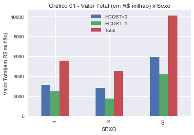

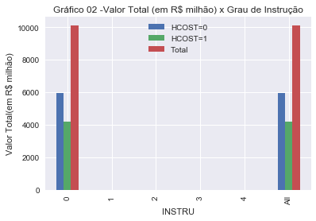

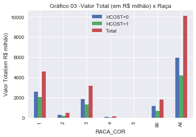

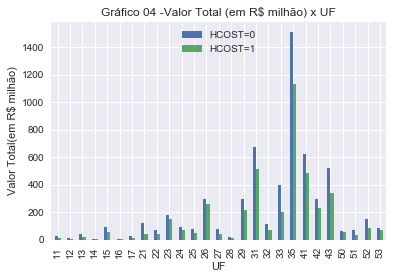

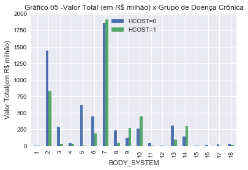

```python
#Visualização dos dados
sns.set()
graf01=data.pivot_table('VAL_TOT', index='SEXO', columns='H_COST', aggfunc=[lambda x: x.sum()/1000000], margins=True).plot(kind= 'bar')
plt.legend(('HCOST=0', 'HCOST=1', 'Total'), loc='upper center', shadow=True)
plt.ylabel("Valor Total(em R$ milhão)")
plt.title ("Gráfico 01 - Valor Total (em R$ milhão) x Sexo")

graf02=data.pivot_table('VAL_TOT', index='INSTRU', columns='H_COST', aggfunc=[lambda x: x.sum()/1000000], margins=True).plot(kind= 'bar')
plt.legend(('HCOST=0', 'HCOST=1', 'Total'), loc='upper center', shadow=True)
plt.ylabel("Valor Total(em R$ milhão)")
plt.title ("Gráfico 02 -Valor Total (em R$ milhão) x Grau de Instrução")

graf03=data.pivot_table('VAL_TOT', index='RACA_COR', columns='H_COST', aggfunc=[lambda x: x.sum()/1000000], margins=True).plot(kind= 'bar')
plt.legend(('HCOST=0', 'HCOST=1', 'Total'), loc='upper center', shadow=True)
plt.ylabel("Valor Total(em R$ milhão)")
plt.title ("Gráfico 03 -Valor Total (em R$ milhão) x Raça")

graf04=data.pivot_table('VAL_TOT', index='UF', columns='H_COST', aggfunc=[lambda x: x.sum()/1000000]).plot(kind= 'bar')
plt.legend(('HCOST=0', 'HCOST=1', 'Total'), loc='upper center', shadow=True)
plt.ylabel("Valor Total(em R$ milhão)")
plt.title ("Gráfico 04 -Valor Total (em R$ milhão) x UF")

graf05=data.pivot_table('VAL_TOT', index='BODY_SYSTEM', columns='H_COST', aggfunc=[lambda x: x.sum()/1000000]).plot(kind= 'bar')
plt.legend(('HCOST=0', 'HCOST=1', 'Total'), loc='upper center', shadow=True)
plt.ylabel("Valor Total(em R$ milhão)")
plt.title ("Gráfico 05 -Valor Total (em R$ milhão) x Grupo de Doença Crônica")
```

```python
#Pelos gráficos acima, é possível identificar os seguintes pontos:
#•	Variável SEXO talvez não seja importante na análise, tendo em vista que os valores estão um pouco menores para o sexo feminino (SEXO=3).
#•	Variável INSTRU (Grau de Instrução) poderia ser excluída da análise, tendo em vista que não possui classificações diferentes de 0.
#•	Variável RACA_COR pode ter importância quando RACA_COR=1 (Branca) ou 3 (Parda)
#•	UF=35 (São Paulo), 31 (Minas Gerais) e 41 (Paraná) podem ser relevantes na avaliação de importância de atributos.
#•	Grupo de doenças crônicas 07 (Doenças do aparelho circulatório) e 02 (Neoplasias [tumores]) podem ser relevantes na avaliação de importância de atributos.
```

# Implementação: Pré-processamento dos dados

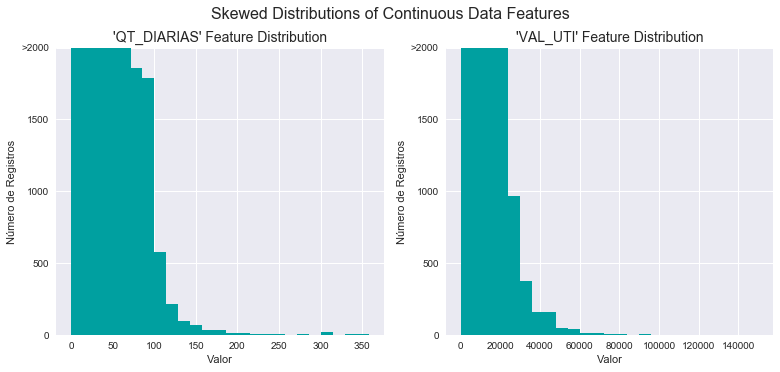

```python
# Divisão dos dados entre features e coluna alvo (H_COST)
H_COST_raw = data['H_COST']
features_raw = data.drop('H_COST', axis = 1)
# Visualização dos dados originais
vs.distribution(data)
```

# OBS: Como a variável VAL_TOT = VAL_SH + VAL_SP + VAL_SADT + VAL_RN + VAL_ACOMP + VAL_ORTP + VAL_SANGUE + VAL_SADTSR + VAL_TRANSP + VAL_OBSANG + VAL_PED1AC, ela será retirada da modelagem a partir de agora, assim como as variáveis que a compõem para evitar problemas de multicolinearidade.

Além disso, as variáveis PERCENTIL95 e HCOST foram calculadas diretamente a partir de VAL_TOT, o que na modelagem dará uma relação praticamente direta, não representando os objetivos desse projeto.

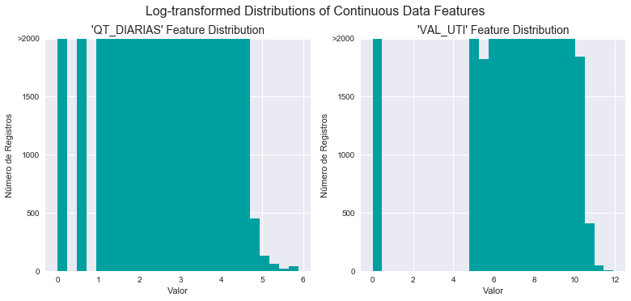

```python
# Aplicação da transformação de log:
skewed = ['QT_DIARIAS', 'VAL_UTI']

features_log_transformed = pd.DataFrame(data = features_raw)
features_log_transformed[skewed] = features_raw[skewed].apply(lambda x: np.log(x + 1))

# Visualização das novas distribuições após a transformação.
vs.distribution(features_log_transformed, transformed = True)
```

### Normalização dos atributos numéricos

```python
# Importação do sklearn.preprocessing.StandardScaler
from sklearn.preprocessing import MinMaxScaler

# Inicialização do aplicador de escala e aplicação aos atributos
scaler = MinMaxScaler()
numerical = ['IDADE', 'QT_DIARIAS', 'VAL_UTI']

features_log_minmax_transform = pd.DataFrame(data = features_log_transformed)
features_log_minmax_transform[numerical] = scaler.fit_transform(features_log_transformed[numerical])

#Exclusão da variável VAL_TOT e da variável INSTRU, que tinha valores concentrados em uma única classificação:
features_log_minmax_transform = features_log_minmax_transform.drop(['VAL_TOT','VAL_SH', 'VAL_SP', 'INSTRU'], axis = 1)

# Exibição dos 10 primeiros registros com a escala aplicada
display(features_log_minmax_transform.head(n=10))
```

|  | UF | SEXO | QT_DIARIAS | VAL_UTI | IDADE | RACA_COR | BODY_SYSTEM |
| --- | --- | --- | --- | --- | --- | --- | --- |
| 0 | 35 | 3 | 0.525391 | 0.0 | 0.466667 | 1 | 3 |
| 1 | 25 | 1 | 0.407575 | 0.0 | 0.293333 | 4 | 3 |
| 2 | 31 | 1 | 0.186733 | 0.0 | 0.213333 | 3 | 3 |
| 4 | 31 | 1 | 0.560200 | 0.0 | 0.786667 | 99 | 3 |
| 5 | 29 | 1 | 0.186733 | 0.0 | 0.226667 | 99 | 3 |
| 6 | 51 | 1 | 0.186733 | 0.0 | 0.946667 | 3 | 3 |
| 8 | 35 | 1 | 0.186733 | 0.0 | 0.800000 | 3 | 3 |
| 9 | 42 | 1 | 0.186733 | 0.0 | 0.280000 | 1 | 3 |
| 10 | 53 | 1 | 0.117816 | 0.0 | 0.080000 | 3 | 3 |
| 11 | 25 | 1 | 0.407575 | 0.0 | 0.480000 | 3 | 3 |

### Conversão de variáveis categóricas por meio da estratégia "one-hot encoding".

```python
#One-hot encoding nos dados em 'features_log_minmax_transform' utilizando pandas.get_dummies()
features_final = pd.get_dummies(features_log_minmax_transform)
#features_final = pd.get_dummies(features_log_minmax_transform, sparse=True)

# Encode da coluna 'H_COST_raw' para valores numéricos
H_COST = H_COST_raw.apply(lambda x: 0 if x==0 else 1)

# Número de colunas depois do one-hot encoding
encoded = list(features_final.columns)
print ("{} total de atributos após aplicar o one-hot encoding.".format(len(encoded)))

print (encoded)
```

[output not shown]

### Embaralhamento e divisão dos dados

Com todas as variáveis de categoria como atributos numéricos e todos os atributos numéricos normalizados, eu dividi os dados em conjuntos de treinamento e de teste (70% dos dados serão utilizados para treinamento e 30% para teste).

```python
# Importação do train_test_split
#from sklearn.cross_validation import train_test_split
from sklearn.model_selection import train_test_split

# Divisão dos 'atributos' e 'H_COST' entre conjuntos de treinamento e de testes.
X_train, X_test, y_train, y_test = train_test_split(features_final,
                                                    H_COST_raw,
                                                    test_size = 0.3,
                                                    random_state = 0)

# Mostrando os resultados da divisão dos dados
print ("Conjunto de Treinamento possui {:0,} amostras.".format(X_train.shape[0]))
print ("Conjunto de Testes possui {:0,} amostras.".format(X_test.shape[0]))
```

```
Conjunto de Treinamento possui 3,697,638 amostras.
Conjunto de Testes possui 1,584,703 amostras.
```

# Avaliação da performance do modelo

Nesta etapa, serão investigados quatro algoritmos diferentes, sendo determinado posteriormente qual deles é melhor para a modelagem dos dados. Três destes algoritmos serão algoritmos de aprendizado supervisionado e o quarto algoritmo será o *naive predictor*.

### Métricas utilizadas

Estimativas indicam que 10% dos pacientes portadores de doenças crônicas representam 2/3 dos custos totais com saúde no Brasil. Desta forma, o objetivo deste projeto será predizer com acurácia quais indivíduos possuem maior risco de ser um paciente de alto custo (H_COST). Usar a acurácia como uma métrica para avaliar a performance de um modelo é um parâmetro adequado. Assim, a habilidade do modelo em predizer com precisão aqueles que possuem alto custo é mais importante do que realizar o recall destes indivíduos. Também será utilizada a fórmula F-beta score como uma métrica que considera ambos: precision e recall.

```python
# Calculo do accuracy, precision e recall
accuracy = n_maior_p95 / n_registros
recall = n_maior_p95 / (n_maior_p95+0)
precision = n_maior_p95 / (n_maior_p95+n_ate_p95)

#Cálculo do F-score utilizando a fórmula para o beta = 0.5 e os valores corretos de precision e recall.
fscore = (1+0.5*0.5)*(recall*precision)/((0.5*0.5 *precision)+recall)

# Resultados
print ("Naive Predictor: [Accuracy score: {:.4f}, F-score: {:.4f}]".format(accuracy, fscore))
```

```
Naive Predictor: [Accuracy score: 0.0500, F-score: 0.0617]
```

## Implementação - Criação do Pipeline de Treinamento e Predição

Nesta etapa, serão criados os pipelines de treinamento e predição para treinar os modelos utilizando vários tamanhos de conjuntos de dados para treinamento, além de performar predições nos dados de teste.

```python
#Importação do fbeta_score e accuracy_score do sklearn.metrics

from sklearn.metrics import fbeta_score
from sklearn.metrics import accuracy_score

def train_predict (learner, sample_size, X_train, y_train, X_test, y_test):

    results = {}

    start = time()
    learner = learner.fit(X_train[:sample_size],y_train[:sample_size])
    end = time()

    #Calculando o tempo de treinamento
    results['train_time'] = end - start

    # Predições do set de treinamento (X_test)
    # Predições das primeiros 300 amostras de treinamento
    start = time()
    predictions_test = learner.predict (X_test)
    predictions_train = learner.predict (X_train[:300])
    end = time()

    # Cálculo do tempo total de predição
    results['pred_time'] = end - start

    # Cálculo do accuracy das primeiros 300 amostras de treinamento y_train[:300]
    results['acc_train'] = accuracy_score (y_true=y_train[:300],y_pred=predictions_train)

    # Cálculo do accuracy no set de testes
    results['acc_test'] = accuracy_score (y_true=y_test,y_pred=predictions_test)

    # Cálculo do F-score das primeiros 300 amostras de treinamento usando fbeta_score()
    results['f_train'] = fbeta_score (y_true=y_train[:300],y_pred=predictions_train,beta=0.5)

    # Cálculo do F-score no set de testes y_test
    results['f_test'] = fbeta_score (y_true=y_test,y_pred=predictions_test,beta=0.5)

    # Print dos Resultados
    print ("{} treinado em {} amostras.".format(learner.__class__.__name__, sample_size))

    # Resultados
    return results
```

# Implementação: Validação inicial do modelo

Nesta etapa serão executadas as seguintes atividades:

- Importação dos três modelos de aprendizado supervisionado escolhidos.
- Inicialização dos três modelos e armazenamento nas variáveis `'clf_A'`, `'clf_B'`, e `'clf_C'`.
- Cálculo do número de registros equivalentes à 1%, 10%, e 100% dos dados de treinamento.
- Armazenamento dos valores em `'amostra_1'`, `'amostra_10'`, e `'amostra_100'` respectivamente.

```
GaussianNB treinado em 36976 amostras.
GaussianNB treinado em 369764 amostras.
GaussianNB treinado em 3697638 amostras.
DecisionTreeClassifier treinado em 36976 amostras.
DecisionTreeClassifier treinado em 369764 amostras.
DecisionTreeClassifier treinado em 3697638 amostras.
LogisticRegression treinado em 36976 amostras.
LogisticRegression treinado em 369764 amostras.
LogisticRegression treinado em 3697638 amostras.
```

[figure not shown]

```python
# Importação dos 3 modelos de aprendizado supervisionado da sklearn
from sklearn.naive_bayes import GaussianNB
from sklearn.tree import DecisionTreeClassifier
from sklearn.ensemble import RandomForestClassifier
from sklearn.ensemble import AdaBoostClassifier
from sklearn.linear_model import LogisticRegression

#from sklearn.svm import SVC

# Inicializando os três modelos
clf_A = GaussianNB()
clf_B = DecisionTreeClassifier(random_state=100)
clf_C = LogisticRegression(random_state=100)


# Número de amostras para 1%, 10%, e 100% dos dados de treinamento
amostra_100 = len(X_train)
amostra_10 = int(round(len(X_train) / 10))
amostra_1 = int(round(len(X_train) / 100))

# Coletando os resultados dos algoritmos de aprendizado
results = {}
for clf in [clf_A, clf_B, clf_C]:
    clf_name = clf.__class__.__name__
    results[clf_name] = {}
    for i, samples in enumerate([amostra_1, amostra_10, amostra_100]):
        results[clf_name][i] = \
        train_predict(clf, samples, X_train, y_train, X_test, y_test)

# Visualização das métricas para os 3 modelos escolhidos:
vs.evaluate(results, accuracy, fscore)
```

```python
#Visualização da tabela com as métricas calculadas:
for i in results.items():
    print (i[0])
    display (pd.DataFrame (i[1]))
```

```
GaussianNB
```

|  | 0 | 1 | 2 |
| --- | --- | --- | --- |
| acc_test | 0.400686 | 0.439646 | 0.470536 |
| acc_train | 0.416667 | 0.433333 | 0.453333 |
| f_test | 0.091047 | 0.095752 | 0.099592 |
| f_train | 0.066667 | 0.068493 | 0.070822 |
| pred_time | 6.842703 | 8.945086 | 8.397541 |
| train_time | 0.111702 | 1.849056 | 30.536718 |

```
DecisionTreeClassifier
```

|  | 0 | 1 | 2 |
| --- | --- | --- | --- |
| acc_test | 0.941942 | 0.950148 | 0.956517 |
| acc_train | 0.996667 | 0.993333 | 0.986667 |
| f_test | 0.421551 | 0.487721 | 0.548676 |
| f_train | 0.978261 | 0.952381 | 0.882353 |
| pred_time | 2.485325 | 4.048189 | 1.297529 |
| train_time | 1.209791 | 14.006082 | 246.335274 |

```
LogisticRegression
```

|  | 0 | 1 | 2 |
| --- | --- | --- | --- |
| acc_test | 0.955101 | 0.955155 | 0.955325 |
| acc_train | 0.970000 | 0.970000 | 0.970000 |
| f_test | 0.495479 | 0.502362 | 0.504946 |
| f_train | 0.500000 | 0.526316 | 0.526316 |
| pred_time | 0.612362 | 0.573044 | 0.714092 |
| train_time | 0.623370 | 2.916202 | 33.347829 |

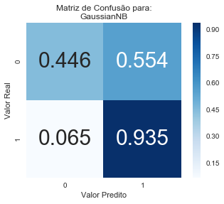

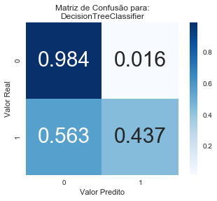

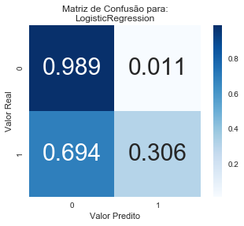

```python
#Visualização da matriz de confusão para cada modelo
from sklearn.metrics import confusion_matrix
import seaborn as sns

for i,model in enumerate([clf_A,clf_B,clf_C]):
    cm = confusion_matrix(y_test, model.predict(X_test))
    cm = cm.astype('float') / cm.sum(axis=1)[:, np.newaxis]

    # Colocando em formato de heatmap
    plt.figure(i)
    sns.heatmap(cm, annot=True, annot_kws={"size":30},
            cmap='Blues', square=True, fmt='.3f')
    plt.ylabel('Valor Real')
    plt.xlabel('Valor Predito')
    plt.title('Matriz de Confusão para:\n{}'.format(model.__class__.__name__))
```

# Aprimorando os resultados

Nesta etapa, será realizado o GridSearch para otimização em todo o conjunto de dados de treino (`X_train` e `y_train`) por meio do tuning de pelo menos um parâmetro, com o objetivo de verificar se é possível melhorar o F-score anterior do modelo, único parâmetro que precisaria ser melhorado.

Cabe destacar que, quando comparado com o Naive Predictor (Accuracy score: 0.0500, F-score: 0.0617), os resultados do modelo escolhido melhoraram consideravelmente.

Devido às similaridades entre os resultados, executei o GriSearch nos dois modelos.

# Grid search com Logistic Regression

```python
from sklearn.model_selection import GridSearchCV
from sklearn.metrics import make_scorer
from sklearn.tree import DecisionTreeClassifier
from sklearn.ensemble import AdaBoostClassifier
from sklearn.linear_model import LogisticRegression
import numpy as np
from sklearn.metrics import fbeta_score, accuracy_score


clf = LogisticRegression(random_state=0)


# Parâmetros para refinar
parameters = {'solver': ('newton-cg', 'lbfgs'), 'multi_class': ('ovr', 'multinomial'), 'C':[0.25, 0.5, 0.75, 1.0]}


scorer = make_scorer(fbeta_score, beta=.5)

grid_obj = GridSearchCV(clf, parameters, scoring=scorer)

grid_start = time()
grid_fit = grid_obj.fit(X_train,y_train)


best_clf = grid_fit.best_estimator_
grid_end = time()
grid_time = grid_end - grid_start

# Predições utilizando o modelo não otimizado e modelagem
unop_start = time()
predictions = (clf.fit(X_train, y_train)).predict(X_test)
best_predictions = best_clf.predict(X_test)
unop_end = time()
unop_time = unop_end - unop_start


# Print dos scores de antes e de depois
print ("Modelo não otimizado\n------")
print ("Score accuracy nos dados de teste: {:.4f}".format(accuracy_score(y_test, predictions)))
print ("F-score nos dados de teste: {:.4f}".format(fbeta_score(y_test, predictions, beta = 0.5)))
print ("train+pred tempo: {:.2f} segs".format(unop_time))
print ("\nModelo Otimizado\n------")
print ("Score final accuracy nos dados de teste: {:.4f}".format(accuracy_score(y_test, best_predictions)))
print ("F-score final nos dados de teste: {:.4f}".format(fbeta_score(y_test, best_predictions, beta = 0.5)))
print ("train+pred tempo: {:.2f} seg".format(grid_time))
print (best_clf)
```

[output not shown]

# Grid search com Decision Tree

```python
from sklearn.model_selection import GridSearchCV
from sklearn.metrics import make_scorer
from sklearn.tree import DecisionTreeClassifier
from sklearn.ensemble import AdaBoostClassifier
from sklearn.linear_model import LogisticRegression
import numpy as np
from sklearn.metrics import fbeta_score, accuracy_score


clf = DecisionTreeClassifier()


# Parâmetros para refinar
parameters = {'criterion':('gini', 'entropy'), 'splitter':('best', 'random'), 'class_weight':('balanced', None), \
             'random_state':[0, 1, None]}

scorer = make_scorer(fbeta_score, beta=.5)

grid_obj = GridSearchCV(clf, parameters, scoring=scorer)

grid_start = time()
grid_fit = grid_obj.fit(X_train,y_train)


best_clf = grid_fit.best_estimator_
grid_end = time()
grid_time = grid_end - grid_start

# Predições utilizando o modelo não otimizado e modelagem
unop_start = time()
predictions = (clf.fit(X_train, y_train)).predict(X_test)
best_predictions = best_clf.predict(X_test)
unop_end = time()
unop_time = unop_end - unop_start


# Print dos scores de antes e de depois
print ("Modelo não otimizado\n------")
print ("Score accuracy nos dados de teste: {:.4f}".format(accuracy_score(y_test, predictions)))
print ("F-score nos dados de teste: {:.4f}".format(fbeta_score(y_test, predictions, beta = 0.5)))
print ("train+pred tempo: {:.2f} segs".format(unop_time))
print ("\nModelo Otimizado\n------")
print ("Score final accuracy nos dados de teste: {:.4f}".format(accuracy_score(y_test, best_predictions)))
print ("F-score final nos dados de teste: {:.4f}".format(fbeta_score(y_test, best_predictions, beta = 0.5)))
print ("train+pred tempo: {:.2f} seg".format(grid_time))
print (best_clf)
```

```
Modelo não otimizado
------
Score accuracy nos dados de teste: 0.9564
F-score nos dados de teste: 0.5476
train+pred tempo: 88.29 segs

Modelo Otimizado
------
Score final accuracy nos dados de teste: 0.9566
F-score final nos dados de teste: 0.5498
train+pred tempo: 4245.96 seg
DecisionTreeClassifier(class_weight=None, criterion='entropy', max_depth=None,
            max_features=None, max_leaf_nodes=None,
            min_impurity_decrease=0.0, min_impurity_split=None,
            min_samples_leaf=1, min_samples_split=2,
            min_weight_fraction_leaf=0.0, presort=False, random_state=None,
            splitter='random')
```

## Avaliação de Importância dos atributos

Foi escolhido o classificador adaboost da scikit-learn utilizando-se a função "feature_importance", que calcula o ranking de importância dos atributos de acordo com o classificador escolhido (serão determinados os 5 atributos mais importantes do conjunto de dados).

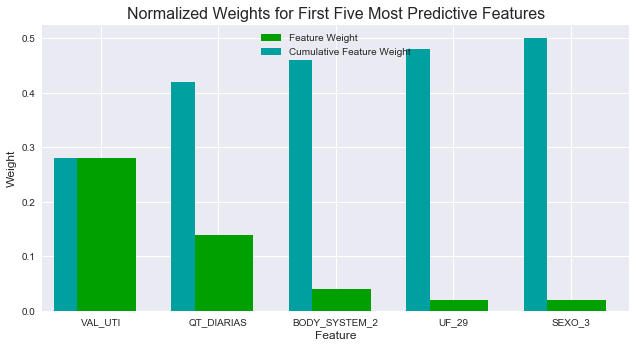

```python
#Extraindo a importância do atributo
from sklearn.ensemble import AdaBoostClassifier
#from sklearn.ensemble import RandomForestClassifier

# Treinamento do modelo utilizando o conjunto de treinamento com .fit(X_train, y_train)
model = AdaBoostClassifier().fit(X_train,y_train)
#model = RandomForestClassifier(random_state=0).fit(X_train, y_train)

model.fit(X_train, y_train)

# Extração da importância dos atributos utilizando .feature_importances_
importances = model.feature_importances_

# Gráfico
vs.feature_plot(importances, X_train, y_train)
indices = np.argsort(importances)[::-1]
columns = X_train.columns.values[indices[:5]]
values = importances[indices][:5]
```

### Seleção de atributos

```python
# Funcionalidade para clonar um modelo
from sklearn.base import clone

# Redução da quantidade de atributos
X_train_reduced = X_train[X_train.columns.values[(np.argsort(importances)[::-1])[:5]]]
X_test_reduced = X_test[X_test.columns.values[(np.argsort(importances)[::-1])[:5]]]

# Treinamento do melhor modelo encontrado com a busca grid anterior
clf = (clone(best_clf)).fit(X_train_reduced, y_train)

# Novas predições
reduced_predictions = clf.predict(X_test_reduced)

# Print dos scores do modelo final utilizando as duas versões dos dados.
print ("Modelo final treinado em todos os dados\n------")
print ("Accuracy nos dados de teste: {:.4f}".format(accuracy_score(y_test, best_predictions)))
print ("F-score nos dados de teste: {:.4f}".format(fbeta_score(y_test, best_predictions, beta = 0.5)))
print ("\nModelo final treinado em dados reduzidos\n------")
print ("Accuracy nos dados de teste: {:.4f}".format(accuracy_score(y_test, reduced_predictions)))
print ("F-score nos dados de teste: {:.4f}".format(fbeta_score(y_test, reduced_predictions, beta = 0.5)))
```

[output not shown]